Soumya Ganguly

2023-03-09

# Introduction

The formulation of a hypothesis is an essential step in any research study. It helps to provide a direction to the research by creating a framework to test assumptions and make predictions about the phenomenon being studied. In this assignment, we will follow the steps involved in formulating a hypothesis. Firstly, we will generate a set of variables that can potentially affect the phenomenon being studied. Next, we will load and compare the dataset to the generated hypothesis and clean the data to proceed further. Then, we will frame research questions and formulate null and alternative hypotheses. Finally, we will perform exploratory data analysis and hypothesis testing to validate or reject our hypotheses. We will apply this approach to understand if proximity to certain areas of interest increases the overall crime rate, whether previous crime history of a certain type influences subsequent crimes in an area, and whether environmental crimes of a certain type are related to the region of occurrence. The research questions and methods are elaborated further in the Methods section.

Based on analysis two research questions were formulated which are discussed further as hypothesis 1 and hypothesis 2.

#### Hypothesis 1

- **Statement** For a specific region does previous history of crime repeat itself over time?
- **Premise** We can consider crime counts, crime logs and also compare data in two different time frames and try to find out common trends.

#### Null and Alternative Hypotheses

**h0 ->** Previous crime history of certain crime type do not influence subsequent crimes in an area

**ha ->** Previous crime history of certain crime type influences subsequent crimes in an area

#### Hypothesis 2

- **Statement** Proximity to an area of interest affects(increase) the overall crime ## rate for the area?
- **Premise** The purpose of this analysis is to determine if proximity to an area of interest has any effect on the overall crime rate in an area. In this analysis, we will investigate whether the presence of a bank or vault or museum within a certain distance (e.g. 500m or 1km) can be considered as a motivation for a burglary or robbery, and whether this proximity affects the overall crime rate in the area.

#### Null and Alternative Hypotheses

**h0:** Proximity to an area of interest does not affect the crime rate.

**ha:** Proximity to an area of interest affects the crime rate.

# Data

The dataset used is titled as “Regression Practice Dataset, Miami Public Safety”. As the title suggests, it is a dataset related to public safety in the city of Miami, Florida, and is designed for use in regression analysis.

# Methods:

### For Hypothesis 1 the following steps were performed:

1. Firstly, we define the time period of interest (e.g., one year, five years, etc.) and the geographic to be studied.
2. Next, we collect data on the crime type of interest for that time period and area.
3. Create a time series plot of the crime counts over the time period of interest. This will allow us to visualize any trends or patterns in the data over time.
4. Use time series analysis techniques, such as auto-regressive integrated moving average (ARIMA) models, to model the data and identify any significant trends or patterns. Specifically, it can be tested whether the previous crime history of a certain crime type is a significant predictor of subsequent crimes in the area.
5. Next, we use hypothesis testing techniques to test the null and alternative hypotheses you defined.
6. Interpret the results and draw conclusions about whether there is evidence to support the alternative hypothesis that previous crime history of a certain crime type influences subsequent crimes in the area.

### For Hypothesis 2 the following steps were performed:

1. To prove/disprove the second hypothesis we need neighborhood and proximity information. So primary task was to merge the relevant layers which contains neighborhood and proximity information and join the columns with crime-related data.
2. Thereafter, the data was grouped based on a specific crime-type and incident_count for the particular crime-type was computed. This helps in further investigating whether the proximity to a specific region is influencing the incident_count for the specific crime-type.
3. Next, linear regression model was constructed to understand the significance of each of these proximity variables on incident count.
4. Finally, hypothesis test throws clarity whether our investigation lead to any conclusive solution or further investigation was needed.

# Results

## Hypothesis 1 Solution:

```r
# Setting current working directory
setwd("D:/MyWorkspace/AOSD-Course/R-Workspace/MiamiCrimeDataAnalysis/data")


# Load Geo package and read the required layers and working on the hypothesis
miami_data_violent_crimes <- st_read("com_police_data.gpkg", layer = "com_violent_crime_2021_22") %>%
  st_transform(4326) %>%
  st_make_valid() # Make geometries valid
# Filter data to focus on a specific region
region <- st_bbox(c(xmin=-80.31578, ymin=25.70949, xmax=-80.15572, ymax=25.85503), crs=4326) # Change this to the specific region you want to analyze


# Create a spatial object from the bounding box
region_sf <- st_as_sfc(region)
region_buffered <- region_sf %>%
  st_buffer(0.01) # Adjust the buffer distance as needed


# Filter data and perform intersection
miami_filtered_violent_crimes <- miami_data_violent_crimes %>%
  st_intersection(region_buffered)
```

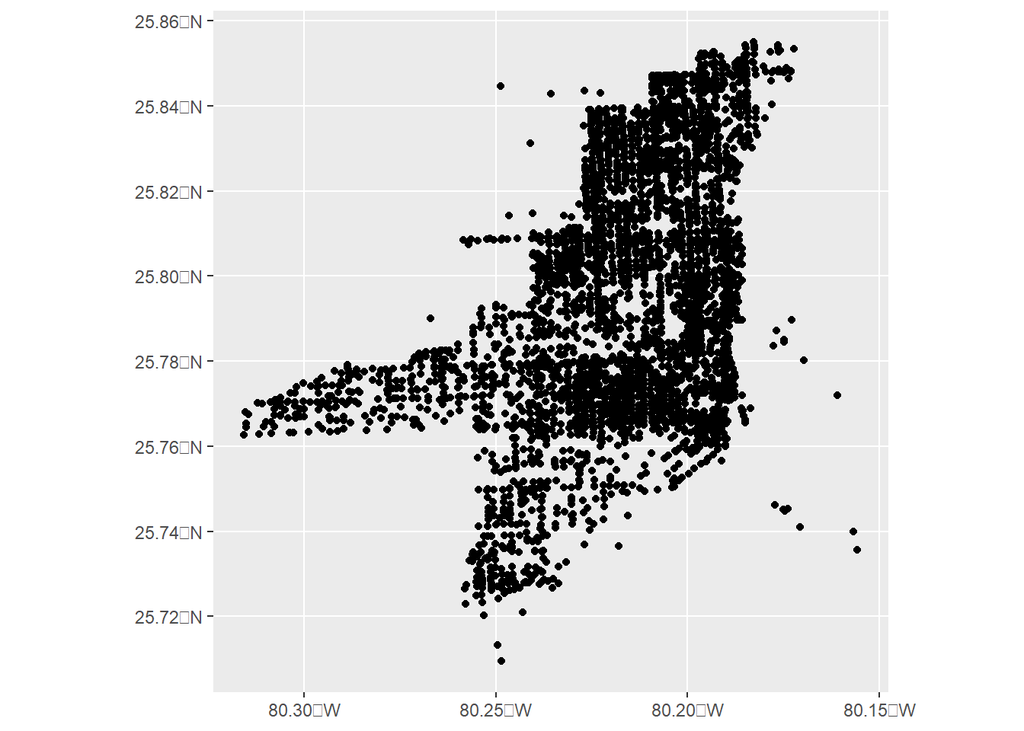

```r
# Plot crime locations to visualize the data
ggplot(miami_filtered_violent_crimes) +
  geom_sf()
```

```r
# set the figure file name and extension
fig.path <- "D:/MyWorkspace/AOSD-Course/R-Workspace/MiamiCrimeDataAnalysis/plot1"
fig.ext <- "html"

# save the plot in the specified format
fig.file <- paste0(fig.path, ".", fig.ext)
knitr::fig_path(fig.file)
```

```
## [1] "Final_Report_files/figure-html/unnamed-chunk-1-1D:/MyWorkspace/AOSD-Course/R-Workspace/MiamiCrimeDataAnalysis/plot1.html"
```

```r
# Calculate crime counts for different time periods and counties
time_periods <- c("2020-01-01/2021-12-31", "2022-01-01/2022-12-31") # Change these to the specific time periods you want to analyze
time_period_breaks <- as.POSIXct(unlist(strsplit(time_periods, "/")), format="%Y-%m-%d") # Convert each element of time_periods to a POSIXct object
crime_counts <- miami_filtered_violent_crimes %>%
  group_by(year=as.numeric(substr(date_eu, 1, 4)), county=as.factor(county), time_period=cut(as.POSIXct(date_eu), breaks=time_period_breaks)) %>%
  summarize(count=n())
```

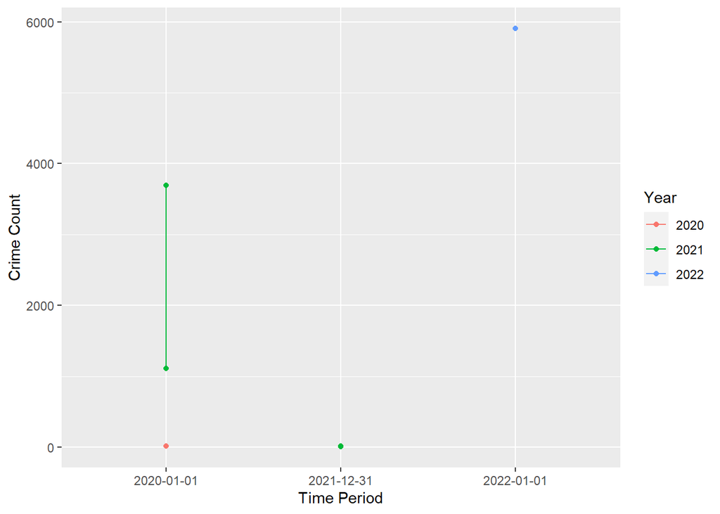

```r
# your code to generate a plot
ggplot(crime_counts, aes(x=time_period, y=count, color=as.factor(year))) +
  geom_point() +
  geom_line() +
  labs(x="Time Period", y="Crime Count", color="Year")
```

```r
# set the figure file name and extension
fig.path <- "D:/MyWorkspace/AOSD-Course/R-Workspace/MiamiCrimeDataAnalysis/plot2"
fig.ext <- "html"

# save the plot in the specified format
fig.file <- paste0(fig.path, ".", fig.ext)
knitr::fig_path(fig.file)
```

```
## [1] "Final_Report_files/figure-html/unnamed-chunk-3-1D:/MyWorkspace/AOSD-Course/R-Workspace/MiamiCrimeDataAnalysis/plot2.html"
```

```r
# Create a contingency table of the counts of the two variables
# To find correlation between yearly crime counts with respect to area
cont_table_year_county <- table(crime_counts$year, crime_counts$county)
chisq_result_year_county <- chisq.test(cont_table_year_county) # Perform the chi-square test on the contingency table
chisq_result_year_county
```

```
##
##  Pearson's Chi-squared test
##
## data:  cont_table_year_county
## X-squared = 1.5, df = 2, p-value = 0.4724
```

```r
chisq_result_year_county$p.value # Check the p-value to determine whether to reject or fail to reject the null hypothesis
```

```
## [1] 0.4723666
```

```r
# To find correlation between crime counts in an area with respect to time period
cont_table_year_period <- table(crime_counts$time_period, crime_counts$county)
chisq_result_year_period <- chisq.test(cont_table_year_period) # Perform the chi-square test on the contingency table
chisq_result_year_period
```

```
##
##  Pearson's Chi-squared test
##
## data:  cont_table_year_period
## X-squared = 0.75, df = 2, p-value = 0.6873
```

```r
chisq_result_year_period$p.value # Check the p-value to determine whether to reject or fail to reject the null hypothesis
```

```
## [1] 0.6872893
```

```r
# Setting current working directory
setwd("D:/MyWorkspace/AOSD-Course/R-Workspace/MiamiCrimeDataAnalysis/data")

# Load Geo package
miami_data <- st_read("com_police_data.gpkg") %>%
  st_transform(4326) %>%
  st_make_valid() # Make geometries valid
```

```
## Multiple layers are present in data source D:\MyWorkspace\AOSD-Course\R-Workspace\MiamiCrimeDataAnalysis\data\com_police_data.gpkg, reading layer `com_burg_epsg3511'.
## Use `st_layers' to list all layer names and their type in a data source.
## Set the `layer' argument in `st_read' to read a particular layer.
```

```r
# List all layer names and their type in the data source
st_layers("com_police_data.gpkg")
```

```
## Driver: GPKG
## Available layers:
##                   layer_name geometry_type features fields
## 1          com_burg_epsg3511         Point     2474     15
## 2                 com_nhoods Multi Polygon      107      5
## 3  com_violent_crime_2021_22         Point    10748     22
## 4         com_voronoi_points         Point     5777      0
## 5       com_voronoi_polygons Multi Polygon     5777      0
## 6       com311_env_crime2021         Point     5639     29
## 7       com311_env_crime2022         Point     4026     29
## 8              mpd_districts Multi Polygon       13      5
## 9            com_police_data         Point     2474     15
## 10              layer_styles            NA        9     12
## 11       com_aggregated_data            NA     5777     98
##                          crs_name
## 1  NAD83(NSRS2007) / Florida East
## 2  NAD83(NSRS2007) / Florida East
## 3  NAD83(NSRS2007) / Florida East
## 4  NAD83(NSRS2007) / Florida East
## 5  NAD83(NSRS2007) / Florida East
## 6  NAD83(NSRS2007) / Florida East
## 7  NAD83(NSRS2007) / Florida East
## 8  NAD83(NSRS2007) / Florida East
## 9  NAD83(NSRS2007) / Florida East
## 10                           <NA>
## 11                           <NA>
```

```r
# Load Geo package and read the required layers and working on the hypothesis
miami_data_violent_crimes <- st_read("com_police_data.gpkg", layer = "com_violent_crime_2021_22") %>%
  st_transform(4326) %>%
  st_make_valid() # Make geometries valid
colnames(miami_data_violent_crimes)
```

```
##  [1] "group"            "crime_type"       "incident_id"      "location"
##  [5] "agency"           "date_unformatted" "county"           "date_eu"
##  [9] "time"             "dttm"             "hour"             "dow"
## [13] "weekday"          "yearmonth"        "week"             "fulladdress"
## [17] "longitude"        "latitude"         "xcoord_ft"        "ycoord_ft"
## [21] "xcoord_m"         "ycoord_m"         "geom"
```

```r
# Get bounding box for entire dataset
bbox_violent_crimes <- st_bbox(miami_data_violent_crimes)

# Print bounding box
bbox_violent_crimes
```

```
##      xmin      ymin      xmax      ymax
## -80.31578  25.70949 -80.15572  25.85503
```

```r
crimes <- unique(miami_data_violent_crimes$crime_type)
print(crimes)
```

```
##   [1] "SIMPLE BATTERY"
##   [2] "ASSAULT / AGG / WITH A DEADLY WEAPON WITHOUT INTENT TO KILL"
##   [3] "SHOOT/THROW DEADLY MISSILES INTO DWELLING, PUBLIC/PRIVATE BLDG/VEHICLE - OCCUPIED, PERSON LISTED AS"
##   [4] "BATTERY (SIMPLE) / PERSON 65 YEARS OF AGE OR OLDER"
##   [5] "BATTERY / PERSON 65 YEARS OF AGE OR OLDER"
##   [6] "BATTERY / SIMPLE"
##   [7] "SIMPLE ASSAULT"
##   [8] "ARMED ROBBERY - FIREARM OR OTHER DEADLY WEAPON"
##   [9] "BATTERY / 1 OR MORE PREVIOUS CONVICTIONS"
##  [10] "AGG ASSAULT / WITH A DEADLY WEAPON WITHOUT INTENT TO KILL"
##  [11] "AGG ASSAULT"
##  [12] "AGGRAVATED BATTERY"
##  [13] "ASSAULT / SIMPLE"
##  [14] "BATTERY / TOUCH OR STRIKE"
##  [15] "AGGRAVATED ASSAULT"
```

[output cut: 110 more lines]

```r
# Filter data to focus on a specific region and crime type
crime_name <- "SIMPLE ASSAULT" # Change this to the specific crime type you want to analyze
region <- st_bbox(c(xmin=-80.31578, ymin=25.70949, xmax=-80.15572, ymax=25.85503), crs=4326) # Change this to the specific region you want to analyze

# Create a spatial object from the bounding box
region_sf <- st_as_sfc(region)
region_buffered <- region_sf %>%
  st_buffer(0.01) # Adjust the buffer distance as needed

# Filter data and perform intersection
miami_filtered_violent_crimes <- miami_data_violent_crimes %>%
  filter(crime_type==crime_name) %>%
  st_intersection(region_buffered)
```

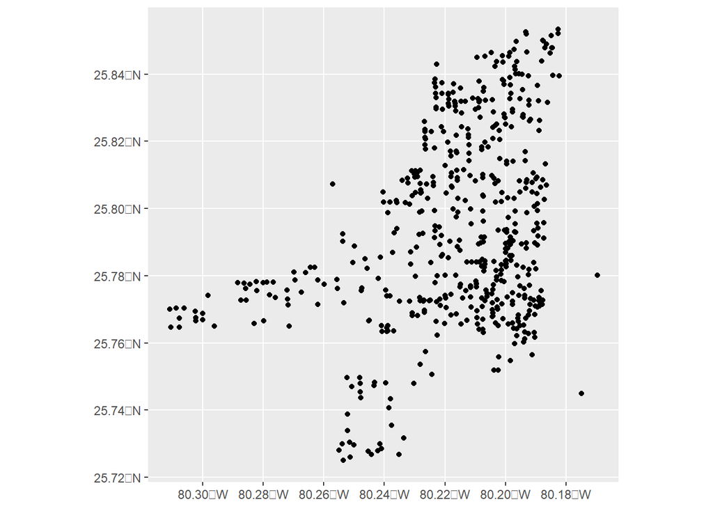

```r
# Plot crime locations to visualize the data
ggplot(miami_filtered_violent_crimes) +
  geom_sf()
```

```r
# set the figure file name and extension
fig.path <- "D:/MyWorkspace/AOSD-Course/R-Workspace/MiamiCrimeDataAnalysis/plot3"
fig.ext <- "html"

# save the plot in the specified format
fig.file <- paste0(fig.path, ".", fig.ext)
knitr::fig_path(fig.file)
```

```
## [1] "Final_Report_files/figure-html/unnamed-chunk-5-1D:/MyWorkspace/AOSD-Course/R-Workspace/MiamiCrimeDataAnalysis/plot3.html"
```

```r
# Calculate crime counts for different time periods and counties
time_periods <- c("2021-11-28/2021-12-28", "2022-01-23/2022-03-31") # Change these to the specific time periods you want to analyze
time_period_breaks <- as.POSIXct(unlist(strsplit(time_periods, "/")), format="%Y-%m-%d") # Convert each element of time_periods to a POSIXct object
crime_counts <- miami_filtered_violent_crimes %>%
  group_by(year=as.numeric(substr(date_eu, 1, 4)), county=as.factor(county), time_period=cut(as.POSIXct(date_eu), breaks=time_period_breaks)) %>%
  summarize(count=n())
```

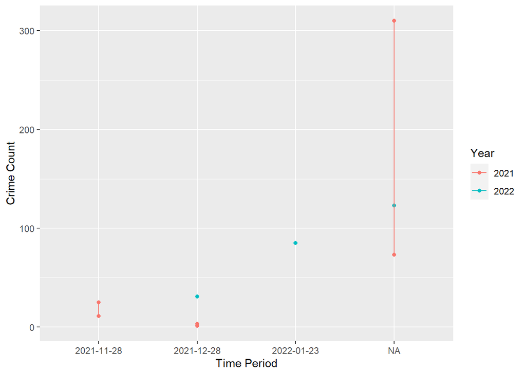

```r
# Plot crime counts over time to visualize trends
ggplot(crime_counts, aes(x=time_period, y=count, color=as.factor(year))) +
  geom_point() +
  geom_line() +
  labs(x="Time Period", y="Crime Count", color="Year")
```

```r
# set the figure file name and extension
fig.path <- "D:/MyWorkspace/AOSD-Course/R-Workspace/MiamiCrimeDataAnalysis/plot4"
fig.ext <- "html"

# save the plot in the specified format
fig.file <- paste0(fig.path, ".", fig.ext)
knitr::fig_path(fig.file)
```

```
## [1] "Final_Report_files/figure-html/unnamed-chunk-7-1D:/MyWorkspace/AOSD-Course/R-Workspace/MiamiCrimeDataAnalysis/plot4.html"
```

```r
# Create a contingency table of the counts of the two variables

# To find correlation between yearly crime counts with respect to area
cont_table_year_county <- table(crime_counts$year, crime_counts$county)
chisq_result_year_county <- chisq.test(cont_table_year_county)
# Perform the chi-square test on the contingency table
chisq_result_year_county
```

```
##
##  Pearson's Chi-squared test with Yates' continuity correction
##
## data:  cont_table_year_county
## X-squared = 0.5625, df = 1, p-value = 0.4533
```

```r
# Check the p-value to determine whether to reject or fail to reject the null hypothesis
chisq_result_year_county$p.value
```

```
## [1] 0.4532547
```

```r
# To find correlation between crime counts in an area with respect to time period
cont_table_year_period <- table(crime_counts$time_period, crime_counts$county)
chisq_result_year_period <- chisq.test(cont_table_year_period)
# Perform the chi-square test on the contingency table
chisq_result_year_period
```

```
##
##  Pearson's Chi-squared test
##
## data:  cont_table_year_period
## X-squared = 0.75, df = 2, p-value = 0.6873
```

```r
# Check the p-value to determine whether to reject or fail to reject the null hypothesis
chisq_result_year_period$p.value
```

```
## [1] 0.6872893
```

```r
# Setting current working directory
setwd("D:/MyWorkspace/AOSD-Course/R-Workspace/MiamiCrimeDataAnalysis/data")


# Load Geo package and read the required layers and working on the hypothesis
miami_data <- st_read("com_police_data.gpkg", layer = "com_violent_crime_2021_22") %>%
  st_transform(4326) %>%
  st_make_valid() # Make geometries valid
# Filter the dataset to only include the crime type and area of interest
crime_name <- "SIMPLE ASSAULT"
area <- "City of Miami"
miami_data_filtered <- miami_data %>%
  filter(crime_type == crime_name & county == area)

colnames(miami_data_filtered)
```

```
##  [1] "group"            "crime_type"       "incident_id"      "location"
##  [5] "agency"           "date_unformatted" "county"           "date_eu"
##  [9] "time"             "dttm"             "hour"             "dow"
## [13] "weekday"          "yearmonth"        "week"             "fulladdress"
## [17] "longitude"        "latitude"         "xcoord_ft"        "ycoord_ft"
## [21] "xcoord_m"         "ycoord_m"         "geom"
```

```r
# Calculating incident count every week
miami_data_filtered <- miami_data_filtered %>%
  group_by(week) %>%
  mutate(incident_count = n()) %>%
  ungroup()
# Converting the data frame into a time-series object
miami_df_ts <- ts(miami_data_filtered$incident_count, frequency = 7) # assuming weekly data
```

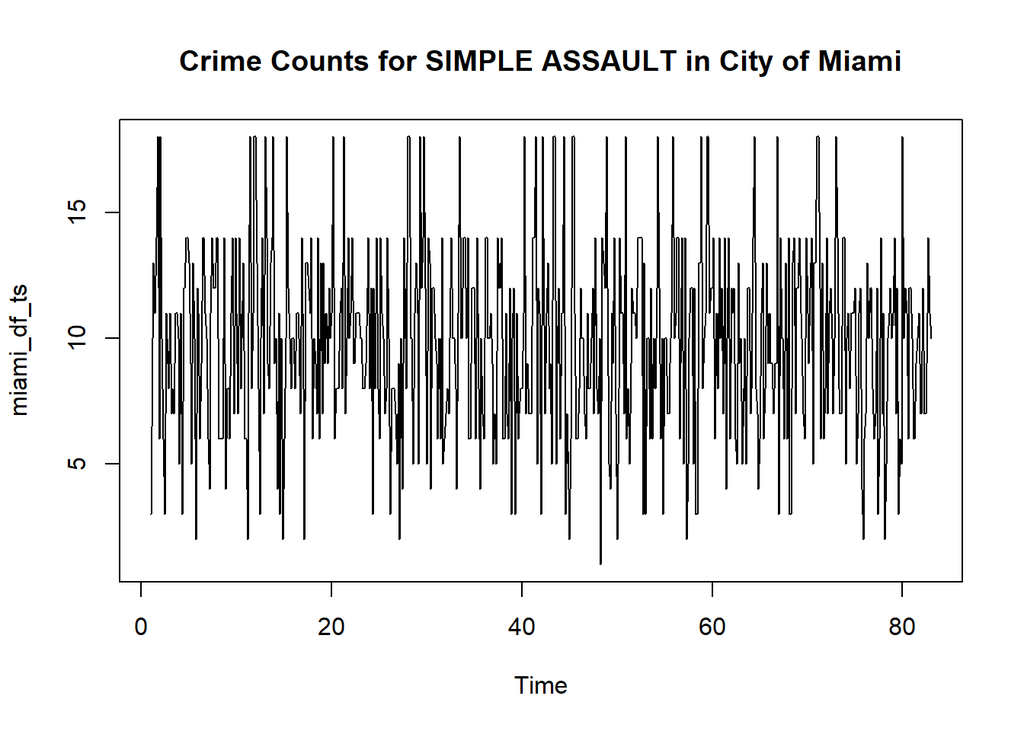

```r
# Create a time series plot of the crime counts
plot(miami_df_ts, main = paste0("Crime Counts for ", crime_name, " in ", area))
```

```r
# set the figure file name and extension
fig.path <- "D:/MyWorkspace/AOSD-Course/R-Workspace/MiamiCrimeDataAnalysis/plot5"
fig.ext <- "html"

# save the plot in the specified format
fig.file <- paste0(fig.path, ".", fig.ext)
knitr::fig_path(fig.file)
```

```
## [1] "Final_Report_files/figure-html/unnamed-chunk-9-1D:/MyWorkspace/AOSD-Course/R-Workspace/MiamiCrimeDataAnalysis/plot5.html"
```

```r
# Fit an ARIMA model to the time series data
arima_model <- auto.arima(miami_df_ts)

# Check the model summary to see the coefficients and significance levels
summary(arima_model)
```

```
## Series: miami_df_ts
## ARIMA(1,0,0)(1,0,0)[7] with non-zero mean
##
## Coefficients:
##          ar1     sar1    mean
##       0.0338  -0.0298  9.8479
## s.e.  0.0418   0.0420  0.1590
##
## sigma^2 = 14.45:  log likelihood = -1582.23
## AIC=3172.46   AICc=3172.53   BIC=3189.88
##
## Training set error measures:
##                        ME     RMSE      MAE       MPE     MAPE      MASE
## Training set 0.0006731799 3.791493 3.070889 -24.99609 46.66343 0.7058944
##                     ACF1
## Training set 0.001453521
```

```r
# Use the model to make predictions for the next 4 weeks
predictions <- forecast(arima_model, h = 4)

# Use hypothesis testing to compare the mean crime count during periods with a high previous # crime history to the mean crime count during periods with a low previous crime history
# For example, we could split the time series data into two groups based on whether the     # crime count in the previous time period was above or below the median, and compare the    # mean crime count for the two groups

prev_crime_history <- miami_df_ts[-1]
prev_crime_median <- median(prev_crime_history)
low_prev_crime <- prev_crime_history[prev_crime_history <= prev_crime_median]
high_prev_crime <- prev_crime_history[prev_crime_history > prev_crime_median]
mean(low_prev_crime)
```

```
## [1] 7.113924
```

```r
mean(high_prev_crime)
```

```
## [1] 13.22481
```

```r
t.test(low_prev_crime, high_prev_crime)
```

```
##
##  Welch Two Sample t-test
##
## data:  low_prev_crime and high_prev_crime
## t = -32.255, df = 554.29, p-value < 2.2e-16
## alternative hypothesis: true difference in means is not equal to 0
## 95 percent confidence interval:
##  -6.483025 -5.738740
## sample estimates:
## mean of x mean of y
##  7.113924 13.224806
```

```r
# Setting current working directory
setwd("D:/MyWorkspace/AOSD-Course/R-Workspace/MiamiCrimeDataAnalysis/data")


# Load Geo package and read the required layers and working on the hypothesis
miami_data <- st_read("com_police_data.gpkg", layer = "com_violent_crime_2021_22") %>%
  st_transform(4326) %>%
  st_make_valid() # Make geometries valid
# Check the structure and summary statistics of the dataset
str(miami_data)
```

```
## Classes 'sf' and 'data.frame':   10748 obs. of  23 variables:
##  $ group           : chr  "Simple Assault" "Aggravated Assault " "Aggravated Assault " "Simple Assault" ...
##  $ crime_type      : chr  "SIMPLE BATTERY" "ASSAULT / AGG / WITH A DEADLY WEAPON WITHOUT INTENT TO KILL" "SHOOT/THROW DEADLY MISSILES INTO DWELLING, PUBLIC/PRIVATE BLDG/VEHICLE - OCCUPIED, PERSON LISTED AS" "SIMPLE BATTERY" ...
##  $ incident_id     : chr  "CM2201220005164" "CM2110060068399" "CM2106240041235" "CM2106010034914" ...
##  $ location        : chr  "SW 74TH AV / SW 8TH ST" "300 BLOCK TAMIAMI CANAL RD" "600 BLOCK TAMIAMI BLVD" "500 BLOCK TAMIAMI BLVD" ...
##  $ agency          : chr  "Miami Police" "Miami Police" "Miami Police" "Miami Police" ...
##  $ date_unformatted: chr  "1-22-2022 3:14 PM" "10/06/2021 15:21" "6-24-2021 4:13 PM" "06/01/2021 18:30" ...
##  $ county          : chr  "City of Miami" "Miami" "City of Miami" "City of Miami" ...
##  $ date_eu         : Date, format: "2022-01-22" "2021-10-06" ...
##  $ time            : chr  "15:14:00" "15:21:00" "16:13:00" "18:30:00" ...
##  $ dttm            : chr  "22/01/2022 15:14:00" "06/10/2021 15:21:00" "24/06/2021 16:13:00" "01/06/2021 18:30:00" ...
##  $ hour            : int  15 15 16 18 0 20 18 21 13 19 ...
##  $ dow             : int  6 3 4 2 3 1 7 7 2 1 ...
##  $ weekday         : chr  "Sat" "Wed" "Thu" "Tue" ...
##  $ yearmonth       : chr  "2022 Jan" "2021 Oct" "2021 Jun" "2021 Jun" ...
##  $ week            : Date, format: "2022-01-17" "2021-10-04" ...
##  $ fulladdress     : chr  "SW 74TH AV / SW 8TH ST, CITY OF MIAMI" "300 BLOCK TAMIAMI CANAL RD, MIAMI" "600 BLOCK TAMIAMI BLVD, CITY OF MIAMI" "500 BLOCK TAMIAMI BLVD, CITY OF MIAMI" ...
##  $ longitude       : num  -80.3 -80.3 -80.3 -80.3 -80.3 ...
##  $ latitude        : num  25.8 25.8 25.8 25.8 25.8 ...
##  $ xcoord_ft       : num  881351 881505 881524 881553 881740 ...
##  $ ycoord_ft       : num  520015 521939 520694 520972 521790 ...
##  $ xcoord_m        : num  268636 268683 268689 268698 268755 ...
##  $ ycoord_m        : num  158501 159087 158708 158792 159042 ...
##  $ geom            :sfc_POINT of length 10748; first list element:  'XY' num  -80.3 25.8
##  - attr(*, "sf_column")= chr "geom"
##  - attr(*, "agr")= Factor w/ 3 levels "constant","aggregate",..: NA NA NA NA NA NA NA NA NA NA ...
##   ..- attr(*, "names")= chr [1:22] "group" "crime_type" "incident_id" "location" ...
```

```r
summary(miami_data)
```

```
##     group            crime_type        incident_id          location
##  Length:10748       Length:10748       Length:10748       Length:10748
##  Class :character   Class :character   Class :character   Class :character
##  Mode  :character   Mode  :character   Mode  :character   Mode  :character
##
##
##
##     agency          date_unformatted      county             date_eu
##  Length:10748       Length:10748       Length:10748       Min.   :2020-12-08
##  Class :character   Class :character   Class :character   1st Qu.:2021-08-11
##  Mode  :character   Mode  :character   Mode  :character   Median :2022-02-02
##                                                           Mean   :2022-01-22
##                                                           3rd Qu.:2022-07-10
##                                                           Max.   :2022-12-22
##      time               dttm                hour            dow
##  Length:10748       Length:10748       Min.   : 0.00   Min.   :1.000
##  Class :character   Class :character   1st Qu.: 7.00   1st Qu.:2.000
##  Mode  :character   Mode  :character   Median :13.00   Median :4.000
##                                        Mean   :12.63   Mean   :4.107
##                                        3rd Qu.:19.00   3rd Qu.:6.000
##                                        Max.   :23.00   Max.   :7.000
##    weekday           yearmonth              week            fulladdress
##  Length:10748       Length:10748       Min.   :2020-12-07   Length:10748
##  Class :character   Class :character   1st Qu.:2021-08-09   Class :character
##  Mode  :character   Mode  :character   Median :2022-01-31   Mode  :character
##                                        Mean   :2022-01-19
##                                        3rd Qu.:2022-07-04
##                                        Max.   :2022-12-19
##    longitude         latitude       xcoord_ft        ycoord_ft
##  Min.   :-80.32   Min.   :25.71   Min.   :881351   Min.   :500810
##  1st Qu.:-80.22   1st Qu.:25.77   1st Qu.:911398   1st Qu.:524100
##  Median :-80.21   Median :25.79   Median :916477   Median :530548
##  Mean   :-80.21   Mean   :25.80   Mean   :914945   Mean   :532095
##  3rd Qu.:-80.20   3rd Qu.:25.82   3rd Qu.:920431   3rd Qu.:540925
##  Max.   :-80.16   Max.   :25.86   Max.   :934095   Max.   :553838
##     xcoord_m         ycoord_m                 geom
##  Min.   :268636   Min.   :152647   POINT        :10748
##  1st Qu.:277795   1st Qu.:159746   epsg:4326    :    0
##  Median :279343   Median :161711   +proj=long...:    0
##  Mean   :278876   Mean   :162183
##  3rd Qu.:280548   3rd Qu.:164874
##  Max.   :284713   Max.   :168810
```

```r
miami_data <- miami_data %>%
  group_by(date_eu) %>%
  mutate(incident_count = n()) %>%
  ungroup()

# Create a linear regression model to predict incident_count based on other variables
model <- lm(incident_count ~ weekday + county + hour + latitude + longitude, data = miami_data)

# Check the model summary to see the coefficients and significance levels
summary(model)
```

```
##
## Call:
## lm(formula = incident_count ~ weekday + county + hour + latitude +
##     longitude, data = miami_data)
##
## Residuals:
##      Min       1Q   Median       3Q      Max
## -18.7188  -3.2289  -0.3328   3.4480  14.9931
##
## Coefficients:
##               Estimate Std. Error t value Pr(>|t|)
## (Intercept) -4.167e+02  1.897e+02  -2.197 0.028035 *
## weekdayMon   1.141e+00  1.721e-01   6.629 3.54e-11 ***
## weekdaySat   1.937e+00  1.706e-01  11.351  < 2e-16 ***
## weekdaySun   3.241e+00  1.670e-01  19.405  < 2e-16 ***
## weekdayThu  -1.210e+00  1.796e-01  -6.738 1.69e-11 ***
## weekdayTue  -6.061e-01  1.768e-01  -3.429 0.000608 ***
## weekdayWed  -1.641e-01  1.759e-01  -0.933 0.350682
## countyMiami -4.327e-01  1.494e-01  -2.896 0.003793 **
## hour        -1.708e-03  6.503e-03  -0.263 0.792835
## latitude     4.608e+00  1.688e+00   2.731 0.006334 **
## longitude   -3.916e+00  2.135e+00  -1.834 0.066677 .
## ---
## Signif. codes:  0 '***' 0.001 '**' 0.01 '*' 0.05 '.' 0.1 ' ' 1
##
## Residual standard error: 4.74 on 10737 degrees of freedom
## Multiple R-squared:  0.09078,    Adjusted R-squared:  0.08994
## F-statistic: 107.2 on 10 and 10737 DF,  p-value: < 2.2e-16
```

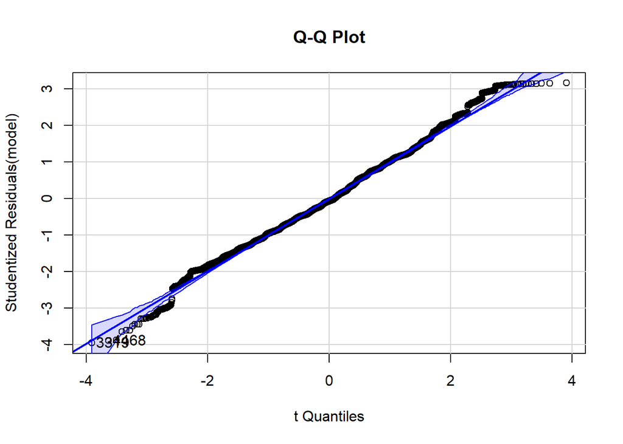

```
## [1] 3319 4468
```

```r
# Check the normality of residuals using a Q-Q plot and a Anderson Darling test
qqPlot(model, main="Q-Q Plot") # requires the car library
```

```r
ad.test(residuals(model))
```

```
##
##  Anderson-Darling normality test
##
## data:  residuals(model)
## A = 13.11, p-value < 2.2e-16
```

```r
# set the figure file name and extension
fig.path <- "D:/MyWorkspace/AOSD-Course/R-Workspace/MiamiCrimeDataAnalysis/plot6"
fig.ext <- "html"

# save the plot in the specified format
fig.file <- paste0(fig.path, ".", fig.ext)
knitr::fig_path(fig.file)
```

```
## [1] "Final_Report_files/figure-html/unnamed-chunk-11-1D:/MyWorkspace/AOSD-Course/R-Workspace/MiamiCrimeDataAnalysis/plot6.html"
```

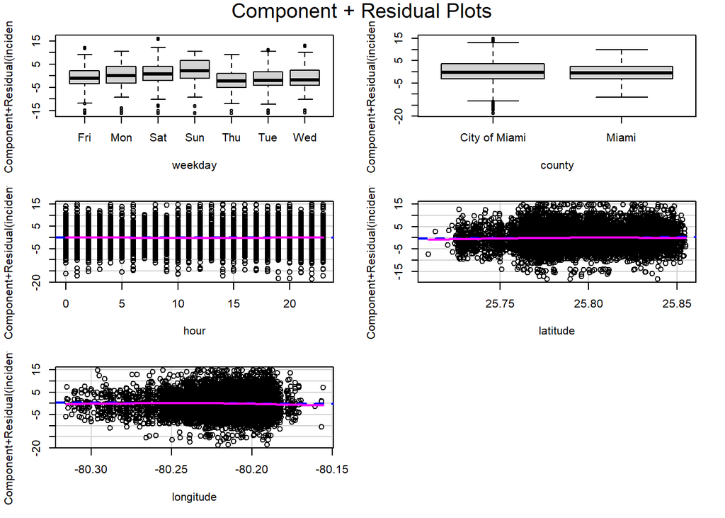

```r
# Check the linearity of the model using a partial residual plot
crPlots(model) # requires the car library
```

```r
# set the figure file name and extension
fig.path <- "D:/MyWorkspace/AOSD-Course/R-Workspace/MiamiCrimeDataAnalysis/plot7"
fig.ext <- "html"

# save the plot in the specified format
fig.file <- paste0(fig.path, ".", fig.ext)
knitr::fig_path(fig.file)
```

```
## [1] "Final_Report_files/figure-html/unnamed-chunk-11-1D:/MyWorkspace/AOSD-Course/R-Workspace/MiamiCrimeDataAnalysis/plot7.html"
```

```r
# In this section , data from 3 different layers were joined and suitable columns
# were extracted. After that frequency/incident_count column was added to proceed further with   # the regression model.

# Setting current working directory
setwd("D:/MyWorkspace/AOSD-Course/R-Workspace/MiamiCrimeDataAnalysis/data")


# Loading crime data and transformation
miami_data <- st_read("com_police_data.gpkg", layer = "com_violent_crime_2021_22") %>%
  st_transform(4326) %>%
  st_make_valid()
# Load the neighbourhood dataset
layer_nhoods <- st_read("com_police_data.gpkg", layer = "com_nhoods") %>%
  st_transform(4326) %>%
  st_make_valid()
# Join the two datasets based on spatial intersection
miami_data_with_neighbourhood <- st_join(layer_nhoods, miami_data)

# Renaming LABEL column in miami_data_with_neighbourhood to neighbourhood
miami_data_with_neighbourhood <- miami_data_with_neighbourhood %>%
  rename(neighbourhood = LABEL)

# Load the aggregated layer dataset
layer_aggregated_data <- read_sf("com_police_data.gpkg", layer = "com_aggregated_data", quiet = TRUE)

# Join the two datasets based on the common attribute neighbourhood
miami_crime_data_with_nhoods_prox <- left_join(miami_data_with_neighbourhood, layer_aggregated_data, by = "neighbourhood")
# Filter dataset for a specific crime (e.g., "Robbery")
specific_crime <- "ROBBERY / ARMED W OTHER THAN DEADLY WEAPON"
filtered_data <- miami_crime_data_with_nhoods_prox %>%
  filter(crime_type == specific_crime)

# Create a new column "incident_count" based on number of crimes per neighborhood
miami_crime_data_optimized <- filtered_data %>%
  group_by(neighbourhood, crime_type, county, geom, dist_bank, dist_convenience, dist_bars, dist450m_bank) %>%
  summarise(incident_count = n())
```

[output not shown]

```r
# Remove any missing data
miami_crime_data_optimized <- na.omit(miami_crime_data_optimized)


# Evaluation and Hypothesis Testing
# Fit the regression model
model <- lm(incident_count ~ dist_bars + dist_convenience, data = miami_crime_data_optimized)

# Print the model summary
summary(model)
```

```
##
## Call:
## lm(formula = incident_count ~ dist_bars + dist_convenience, data = miami_crime_data_optimized)
##
## Residuals:
##     Min      1Q  Median      3Q     Max
## -1.6337 -1.1545 -0.2854  0.8481  1.9151
##
## Coefficients:
##                   Estimate Std. Error t value Pr(>|t|)
## (Intercept)      1.9846109  0.1490420  13.316   <2e-16 ***
## dist_bars        0.0002809  0.0001636   1.716    0.087 .
## dist_convenience 0.0005166  0.0003347   1.544    0.124
## ---
## Signif. codes:  0 '***' 0.001 '**' 0.01 '*' 0.05 '.' 0.1 ' ' 1
##
## Residual standard error: 1.09 on 367 degrees of freedom
## Multiple R-squared:  0.01681,    Adjusted R-squared:  0.01146
## F-statistic: 3.138 on 2 and 367 DF,  p-value: 0.04453
```

```r
# Test the hypothesis using ANOVA
anova(model)
```

```
## Analysis of Variance Table
##
## Response: incident_count
##                   Df Sum Sq Mean Sq F value  Pr(>F)
## dist_bars          1   4.62  4.6247  3.8930 0.04924 *
## dist_convenience   1   2.83  2.8309  2.3831 0.12352
## Residuals        367 435.97  1.1879
## ---
## Signif. codes:  0 '***' 0.001 '**' 0.01 '*' 0.05 '.' 0.1 ' ' 1
```

```r
# Perform the Wilcoxon rank-sum test
wilcox.test(incident_count ~ dist450m_bank, data = miami_crime_data_optimized)
```

```
##
##  Wilcoxon rank sum test with continuity correction
##
## data:  incident_count by dist450m_bank
## W = 9045, p-value = 7.842e-06
## alternative hypothesis: true location shift is not equal to 0
```

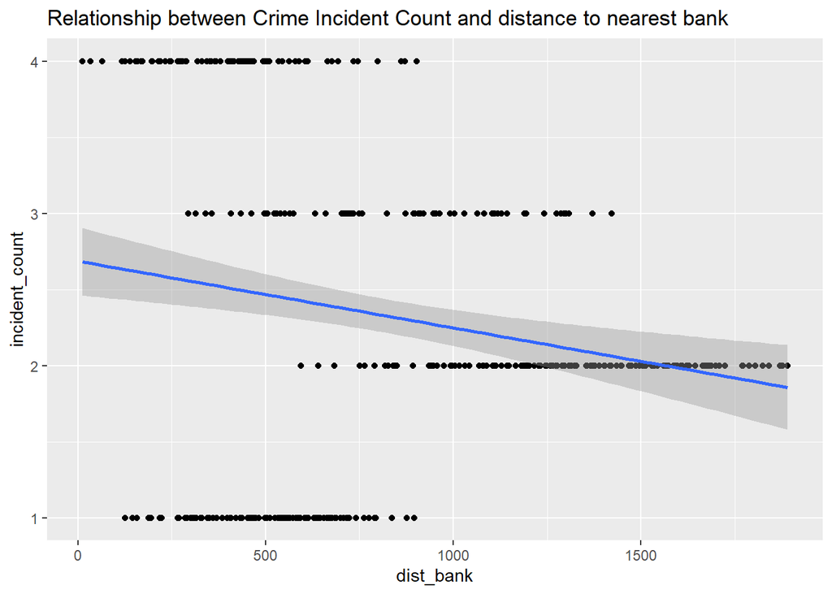

```r
# Visualize the results
ggplot(miami_crime_data_optimized, aes(x = dist_bank, y = incident_count)) +
  geom_point() +
  geom_smooth(method = "lm") +
  labs(title = "Relationship between Crime Incident Count and distance to nearest bank")
```

# Conclusions

### Hypothesis 1:

**Approach 1 and 2** Nothing conclusive could be drawn from the two approaches. Chisquared test suggested a possibility of incorrect evaluation. Also the p values received were much more than 0.05. So the Null Hypothesis cannot be totally ignored.

The Welch two-sample t-test results indicate that there is a significant difference in means between the low_prev_crime and high_prev_crime groups. The p-value is very small (< 2.2e-16), indicating that the null hypothesis of no difference in means can be rejected in favor of the alternative hypothesis of a difference in means. The confidence interval also suggests that the true difference in means between the two groups is not zero.

Overall, these results provide evidence in favor of the alternate hypothesis that there is a difference in crime rates between the low_prev_crime and high_prev_crime groups.

**Approach 4** The following conclusions can be drawn in favor or against the alternate hypothesis:

The coefficients for some of the variables, such as weekday, county, and latitude, are statistically significant (indicated by the **,** , or symbols) at a 5% significance level, which suggests that these variables have a significant effect on the incident_count.

The p-value for the F-statistic is less than 2.2e-16, which indicates that the overall model is significant.

The Adjusted R-squared value is 0.08994, which means that the model explains only 8.994% of the variation in the incident_count.

The Anderson-Darling normality test for the residuals shows a p-value less than 2.2e-16, which indicates that the residuals are not normally distributed. This suggests that the linear regression assumptions may not hold, and the results should be interpreted with caution.

In summary, the model suggests that the weekday, county, and latitude variables have a significant effect on the incident_count. However, the low Adjusted R-squared value and the violation of normality assumptions suggest that the model may not fit the data well. Therefore, further investigation and analysis may be required to draw reliable conclusions.

To summarize, Approach 3 can strongly support in favor of Hypothesis 1.

### Hypothesis 2:

Based on the output, we can draw the following conclusions:

The p-value for dist_bars is 0.087, which is greater than the significance level of 0.05. Therefore, we cannot reject the null hypothesis that proximity to bars does not affect the crime rate.

The p-value for dist_convenience is 0.124, which is also greater than the significance level of 0.05. Therefore, we cannot reject the null hypothesis that proximity to convenience stores does not affect the crime rate.

The Wilcoxon rank sum test shows a p-value of 7.842e-06, which is less than the significance level of 0.05. Therefore, we reject the null hypothesis and conclude that there is a significant difference in incident counts between areas close to and far from banks.

Overall, the results suggest that proximity to bars or convenience stores does not significantly affect the crime rate, but proximity to banks does. However, it is important to note that the adjusted R-squared value is very low, indicating that the model does not explain much of the variation in incident counts. Therefore, further analysis and modeling may be necessary to fully understand the relationship between proximity to different types of areas and crime rates in Miami.

# References

[ARIMA modeling: “Time Series Analysis and Its Applications: With R Examples” by Shumway, R. H., & Stoffer, D. S. (2017)](https://www.researchgate.net/publication/265365840_Time_Series_Analysis_and_Its_Applications_With_R_Examples)

[linear regression and its assumptions: “Linear Models in Statistics”](https://www.utstat.toronto.edu/~brunner/books/LinearModelsInStatistics.pdf)

[A beginner’s guide to understanding p-values](https://www.ncbi.nlm.nih.gov/pmc/articles/PMC3576830/)

[P Values, Hypothesis Testing, and Statistical Significance: A Brief Tutorial](https://www.ncbi.nlm.nih.gov/pmc/articles/PMC5808128/)

[Official Documentation for ARC GIS PRO was helpful](https://pro.arcgis.com/en/pro-app/latest/tool-reference/spatial-statistics/regression-analysis-basics.htm)

[Watched a tutorial for ggplot2](https://towardsdatascience.com/data-visualization-with-ggplot2-db04c4956236)